# Visualization Introduction

## Overview

- What is data visualization?
- Why is it important?
- Goals
- Responsibilities
- Using R

## Data visualization

Data visualization is the graphical representation of information and data.

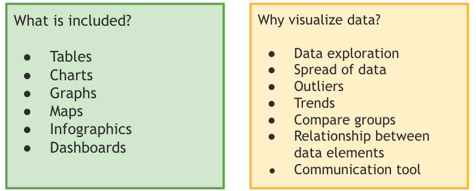

Resources:

- https://hbr.org/2016/06/visualizations-that-really-work
- https://www.data-to-viz.com/

## Data visualization goals

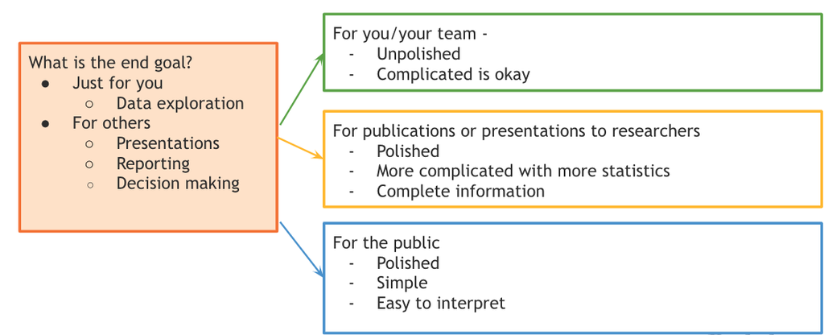

## Data visualization caution/responsibility

There is a responsibility with data visualization to present data in a factual, accurate manner.

Considerations:

- Scale of x-axis and y-axis
- Individual plots
- Comparing plots
- Color/shapes
  - Sufficiently differentiating between groups
- Value exclusions
  - Outliers
  - Axis limitation
- And many more

[figure not shown]

## Data Visualization Best Practices

- Descriptive titles and labels
  - Title can include an interpretation of results (“STD rates, CA 2001-2018” versus “STDs are increasing in all California Counties from 2001-2018”)
- Legends
  - Clearly labeled
  - Meaningful order
- Footnotes
  - Data sources
  - Methods, if relevant
  - Limitations/caveats
- Colors
  - Colorblind friendly
  - Appropriate with scale

**Best practice:** A good rule of thumb is to include all necessary information in a visual so that if someone saw only the visual (no other context), they would have all the information needed to interpret correctly.

## Data Visualization in R

- R is a powerful tool for creating many types of visualizations
  - Tables
  - Graphs
  - Dashboards (R Shiny)
- Quarto and R Markdown are tools for generating presentable tables and graphs
  - PDF
  - Html
  - Microsoft products (Rmd)
- Save graphs or tables as images to copy and paste elsewhere
- Many packages available for additional visualization tools

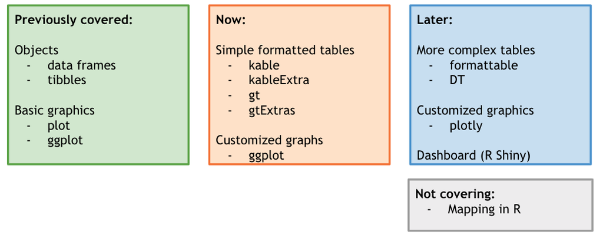

## Getting started

### Factors

- Factors can be used to control the order that values appear in a table and/or plot
- Can be used to assign new order and labels to character and numeric values
- Examples:
  - `factor(example1, ordered=TRUE, levels = c("low", "middle", "high"), labels = c(“l”,”m”,”h”))`
  - `factor(example2, ordered=TRUE, levels = c(3,2,1), labels = c(“l”,”m”,”h”))`

### Data frames (or tibbles)

Before starting to created a formatted table or generate a graph, the original data frame (table) should have been sufficiently tidied

- Limited to only rows and columns desired for the visualizations
- Variables changed to factor to control order
- For tables, get as close to the final format and order as possible
- If needed, a tibble can be converted to a data frame by adding this to the end of dplyr statements `%>% data.frame()`